# Hedonic regression and hedonic indexes

12 Apr 2015

## Analysing real estate market

## Analysing real estate market - basic measures

- descriptive statistics - basic measures and comparisons
- indexes (chain, monthly, quarterly, yearly) - diferent aspects of real estate market
- hedonic regression and extensions - measuring what characteristics of flat/housr affect price or price m2

## Hedonic regression - theoretical aspects

## Hedonic regression - definitions

**Hedonic method/regression** (OECD) is a regression technique used to estimate the prices of qualities or models that are not available on the market in particular periods, but whose prices in those periods are needed in order to be able to construct price relatives.

Assumptions:

- Price is a function of certain characteristics of property (flat, house),
- Relation defined by this function is the same for all types of properties in time \(t\)
- Relation change overtime (\(f(\mathbf{x})_t \neq f(\mathbf{x})_{t-1}\)), thus we can build indexes (hedonic indexes)

**It is not restricted only to real estate market!**

## Hedonic regression - forms (log-log)

The most common forms of hedonic regression are: the log-log, the semilog or the linear.

In the log-log all of the variables are logarithms of original values:

\[ ln f(x_1,x_2,\ldots,x_k) \equiv \alpha_0 + \sum_{k=1}^K \alpha_k ln(x_k) \]

more precise (for price)

\[ ln P_{i}^{t} = \alpha_{0} + \sum_{k=1}^K \alpha_k ln(x_{ik}^t) + \epsilon_{ik}^t \]

## Hedonic regression - forms (semilog)

\[ ln f(x_1,x_2,\ldots,x_k) \equiv \alpha_0 + \sum_{k=1}^K \alpha_k x_k \]

in case of the price

\[ ln P_{i}^{t} = \alpha_{0} + \sum_{k=1}^K \alpha_k x_{ik}^t + \epsilon_{ik}^t \]

## Hedonic regression - forms (linear)

and the linear

\[ f(x_1,x_2,\ldots,x_k) \equiv \alpha_0 + \sum_{k=1}^K \alpha_k x_k \]

in case of the price

\[ P_{i}^{t} = \alpha_{0} + \sum_{k=1}^K \alpha_k x_{ik}^t + \epsilon_{ik}^t \]

## Hedonic regression in real estate market

\[ ln P_{i}^{t} = \alpha_{0} + \sum_{k=1}^K \alpha_k x_{ik}^t + \sum_{t=1}^Tb^tD^t + \epsilon_{ik}^t \]

Where \(D_t\) is a time-dummy variable (for months, quarters, years etc.)

**And this is the most common hedonic regression used in real estate market**.

## Hedonic regression - practical issues

## Hedonic regression - questions

This is the problem of modelling the prices therefore:

- what characteristics should we include in the model?
- how complicated should be the model?
- should we include spatial heterogenity into the model?
- should we include varying intercepts and slopes into model (mixed model, bayesian)?

Of course after the modelling we sould check assumptions of linear regression!

## Hedonic regression - NBP (1)

NBP use hedonic regression to calculate hedonic price index for flats on secondary market using the following characteristics:

- number of floors (continuous variable);
- rooms_dummy - 1 if one or two rooms, else;
- kitchen (3 dummy variables) - 1 = separate dark kitchen, else 0 ; 1= separate bright kitchen, else 0; 1 = kitchenette, else 0;
- district (2 dummy variables) - 1 = average location, else 0; 1 = good location, else 0;
- subdistrict (3 dummy variables);
- floor number (continuous variable);
- year of construction (9 dummy variables,) - before 1918, 1918–1944, 1945–1970, 1971–1978, 1979–1988, 1989–2001, 2002–2005, after 2005, new (1 year before listing);

## Hedonic regression - NBP (2)

- housing coop (1 dummy variable)
- floor area - square root of floor area in m2
- standard of flat finish (4 dummy categories)
- elavator (1 dummy variable)
- building technology (6 dummy variables)

## Hedonic regression - restriction of NBP model (2)

NBP use following restrictions for observations that are modelled

- flats with price m2 <= 18 000 m2
- floor area <= 200 m2
- rooms <= 8
- floor numbers <= 26

## Indexes

- price indexes
- primary market - offers and transactions
- secondary market - offers and transactions
- new buildings and houses
- house mortages and loans

## Hedonic indexes

## Simple hedonic index

**Hedonic index** - an price index that is based on estimates from hedonic regression.

\[ Index = exp(b^{t=2}) \]

where \(b\) is estimated parameter for model with dummy variables \(D\).

Cons:

- Characteristics of flats are constant in time

## Imputation method / Imputation index (1)

We estimate model for \(t+1 (t)\) using characteristics from \(t+1(t)\) time. We obtain parameter estimates and we can construct following indexes:

\[ Index = \frac{\sum_{i=1}^N \frac{1}{N} \hat{p}_i^{t+1}(x_i^t)}{\sum_{i=1}^N \frac{1}{N} p_i^t(x_i^t)} \]

where \(p_i^t(x_i^t)\) are prices from time \(t\) and \(\hat{p}_i^{t+1}(x_i^t)\) are predicted values for \(x_i^t\) using model for \(t+1\).

## Imputation method / Imputation index (2)

The second possibility is:

\[ Index = \frac{\sum_{i=1}^N \frac{1}{N} p_i^{t+1}(x_i^{t+1})}{\sum_{i=1}^N \frac{1}{N} \hat{p}_i^t(x_i^{t+1})} \]

where \(p_i^{t+1}(x_i^{t+1})\) are prices from \(t+1\) and \(\hat{p}_i^t(x_i^{t+1})\) are estimates using model from \(t\) and variables \(x^{t+1}\).

## Hedonic indexes in Poland

## Hedonic indexes for cities in Poland (1)

Now we present hedonic indexes for 16 cities in Poland, that are reported by NBP. NBP construct two types of indexes:

- Quarter to Quarter (chain index); \(p_{q,y}/p_{q-1,y}\)
- Quarter in Year \(y\) to Quarter in Year \(y-1\); \(p_{q,y}/p_{q,y-1}\)

National Bank of Poland uses imputation method for primary and secondary market.

## Hedonic indexes for cities in Poland (2)

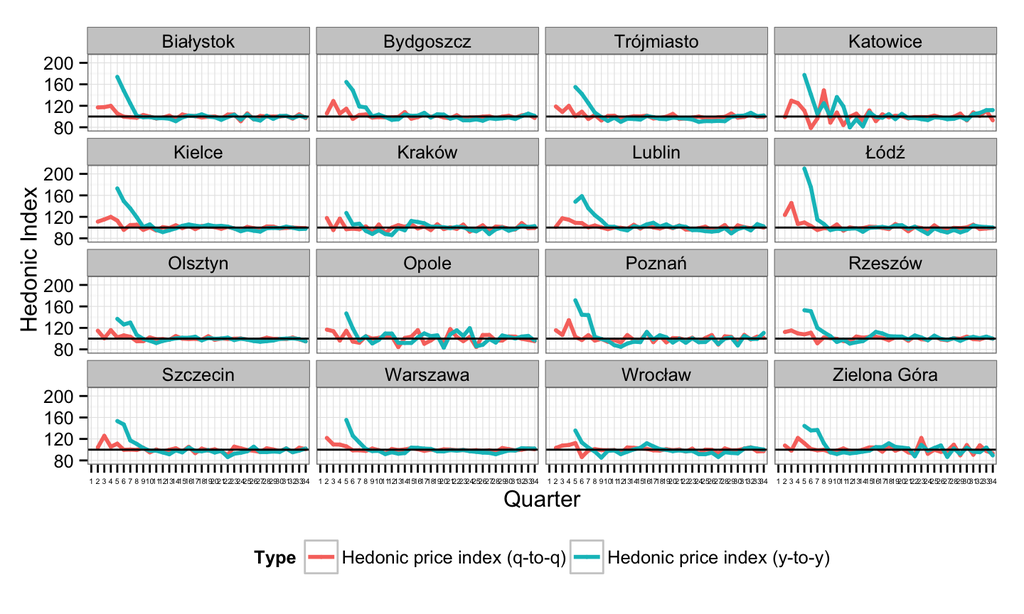